# VIBRANT Trial - Primary Analyses

Author

Laura Symul, Laura Vermeren, Susan Holmes

```r
library(tidyverse)
library(magrittr)
library(gt)
library(patchwork)
library(SummarizedExperiment)
library(tidySummarizedExperiment)
library(brms)
library(gtsummary)
library(labelled)
library(scales)
# library(gridExtra)
library(ggpubr)
# library(mia) # BiocManager::install("mia")

theme_set(theme_light())
tmp <- fs::dir_map("R", source)
```

```r
#data_source <- "real"
```

This document presents the primary analyses of the VIBRANT trial. Currently, this runs on blinded data, and population flags have not yet been fully accounted for.

**Warning**

Population flags still need to be included in the analysis

## Loading the data

> TODO: change path

```r
# mae <- readRDS("/Users/laurasymul/OneDrive - UCL/Academia/Research/VIBRANT data UCLouvain/actual data/03 QCed MAEs/mae_full_20250527.rds")
# mae <- readRDS("/Users/lvermeren/OneDrive - UCL/VIBRANT data UCLouvain/actual data/03 QCed MAEs/mae_full_20250529.rds")
# mae

data_source <- "real"
mae_files <-
  fs::dir_ls(data_dir(data_source = data_source), regexp = "mae_full_.*\\.rds$") |>
  sort(decreasing = TRUE) |>
  magrittr::extract(1)

mae <- readRDS(mae_files)

rm(mae_files)
```

# Analyses

## Demographics (Table 1)

### Summary table

We create a `table1_data` table from the metadata of the `participant_crfs_merged` mae, which contains only the variables needed to create table 1 (`site`, `age`, `race`, `ethn`, `cut_size_meals`, `eat_less`, `hungry_did_not_eat`, `sexual_partners_lifetime`, `sexual_partners_past_month`, `contraception_method` and `group4`) and the participants including in the mITT population.

We create the variable `food_insecurity` based on the three variables `cut_size_meals`, `eat_less` and `hungry_did_not_eat`. If any of these three variables is “Yes”, then the participant is considered to be food insecure.

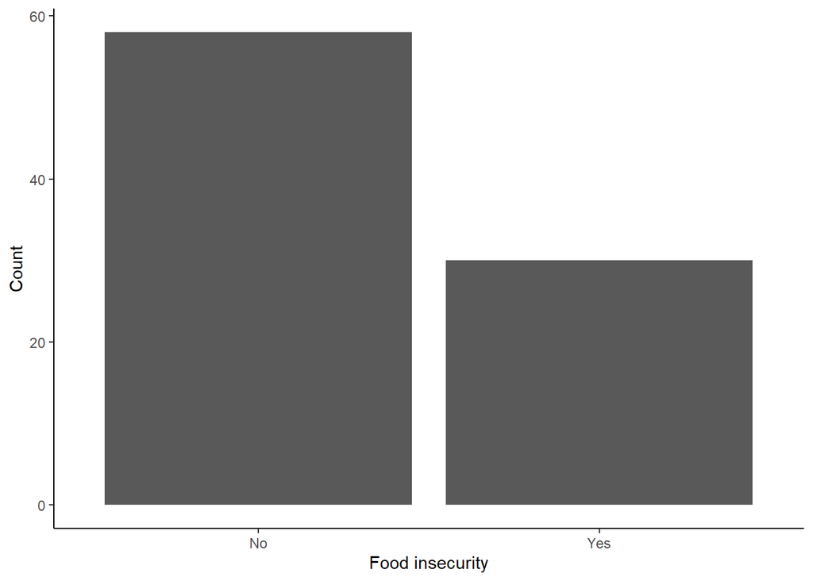

```r
table1_data <-
  metadata(mae)$participant_crfs_merged |>
  left_join(colData(mae) |> as_tibble() |> select(pid, ITT, mITT, PP) |> distinct(), by = "pid") |>
  filter(mITT) |>
  select(pid, site, age, race, ethn, cut_size_meals, eat_less, hungry_did_not_eat, sexual_partners_lifetime, sexual_partners_past_month, contraception_method, group4) |>
  mutate(
    food_insecurity = ifelse(
      cut_size_meals == "Yes" | eat_less == "Yes" | hungry_did_not_eat == "Yes",
      "Yes",
      "No"
    ),
    food_insecurity = factor(food_insecurity, levels = c("No", "Yes"))
  ) |>
  select(-c(eat_less, cut_size_meals, hungry_did_not_eat))


table1_data |>
  ggplot(aes(x = food_insecurity)) +
  geom_bar() +
  labs(x= "Food insecurity", y = "Count")+
  theme_classic()
```

```r
gender_sexual_partner <-
  metadata(mae)$visits_crfs_merged |>
  select(pid, past_week_sex_partner) |>
  filter(!is.na(past_week_sex_partner)) |>
  group_by(pid) |>
  summarise(
    gender_sexual_partner = case_when(
      all(past_week_sex_partner == "No sex in the past week") ~ "No sex",
      any(past_week_sex_partner %in% c("A single male partner", "Multiple male partners")) &
        !any(past_week_sex_partner %in% c("A single female partner", "Multiple female partners")) ~ "Only man",
      any(past_week_sex_partner %in% c("A single female partner", "Multiple female partners")) &
        !any(past_week_sex_partner %in% c("A single male partner", "Multiple male partners")) ~ "Only female",
      any(past_week_sex_partner %in% c("A single male partner", "Multiple male partners")) &
        any(past_week_sex_partner %in% c("A single female partner", "Multiple female partners")) ~ "Both",
      TRUE ~ NA_character_
    ),
    .groups = "drop"
  )

table1_data <-
  table1_data |>
  left_join(gender_sexual_partner, by = "pid")
```

For the time being, participants are randomly assigned to a treatment arm, except for those in group4, who are assigned to the *LC-106-o* arm.

```r
table1_data <-
  table1_data |>

  # randomly assign participants to arms
  mutate(
    arm = case_when(
      group4 == "Yes" ~ "LC-106-o",
      TRUE ~ sample(
        c("Palcebo", "LC-106-7", "LC-106-3", "LC-115"),
        size = n(),
        replace = TRUE
      )
    ),
    across(where(is.character), as.factor),

    race = fct_recode(
      race,
      "Asian" = "Asian or South Asian",
      "Black" = "Black, African American, or African",
      "Black" = "African",
      "Coloured" = "Coloured",
      "White" = "White",
      "Other" = "Other"
    ),

    race = fct_drop(race, only = "Prefer not to answer"),
    race = fct_relevel(race, "Asian", "Black", "Coloured", "White", "Other"),
    arm = fct_relevel(arm, "Palcebo", "LC-106-7", "LC-106-3", "LC-106-o", "LC-115"),
  ) |>

  select(-group4) |>

  set_variable_labels(
    food_insecurity = "Report food insecurity in past 12 months ",
    #gender_sexual_partners = "Gender of sexual partners",
    sexual_partners_past_month = "Number of partners in past month",
    sexual_partners_lifetime = "Number of partners in lifetime",
    ethn = "Ethnicity",
    contraception_method = "Contraception",
    gender_sexual_partner = "Gender of sexual partners"
  )
```

Create Table 1 (by arm)

```r
table1_data |>
  select(-pid) |>
  rename_with(~ str_to_title(.x)) |>
  tbl_summary(
    by = Arm,
    type =
      list(
        Sexual_partners_past_month ~ "continuous",
        Sexual_partners_lifetime ~ "continuous"
      ),
    statistic = list(
      all_continuous() ~ "{mean} ({min}-{max})",
      all_categorical() ~ "{n} ({p}%)"
    )
  )  |>
  add_p()
```

| **Characteristic** | **Palcebo** N = 24<sup>1</sup> | **LC-106-7** N = 16<sup>1</sup> | **LC-106-3** N = 18<sup>1</sup> | **LC-106-o** N = 13<sup>1</sup> | **LC-115** N = 17<sup>1</sup> | **p-value**<sup>2</sup> |
| --- | --- | --- | --- | --- | --- | --- |
| Site |  |  |  |  |  | 0.3 |
| CAP | 20 (83%) | 12 (75%) | 14 (78%) | 12 (92%) | 10 (59%) |  |
| MGH | 4 (17%) | 4 (25%) | 4 (22%) | 1 (7.7%) | 7 (41%) |  |
| Age | 28 (21-40) | 26 (18-34) | 30 (20-39) | 26 (19-35) | 29 (20-40) | 0.2 |
| Race |  |  |  |  |  | >0.9 |
| Asian | 0 (0%) | 1 (6.3%) | 1 (5.6%) | 0 (0%) | 0 (0%) |  |
| Black | 21 (88%) | 14 (88%) | 15 (83%) | 13 (100%) | 14 (82%) |  |
| Coloured | 0 (0%) | 0 (0%) | 0 (0%) | 0 (0%) | 0 (0%) |  |
| White | 2 (8.3%) | 1 (6.3%) | 1 (5.6%) | 0 (0%) | 2 (12%) |  |
| Other | 0 (0%) | 0 (0%) | 1 (5.6%) | 0 (0%) | 1 (5.9%) |  |
| Prefer not to answer | 1 (4.2%) | 0 (0%) | 0 (0%) | 0 (0%) | 0 (0%) |  |
| Ethnicity |  |  |  |  |  | 0.13 |
| Not hispanic/latino/spanish | 1 (25%) | 4 (100%) | 3 (75%) | 1 (100%) | 6 (86%) |  |
| hispanic/latino/spanish | 3 (75%) | 0 (0%) | 1 (25%) | 0 (0%) | 1 (14%) |  |
| Unknown | 20 | 12 | 14 | 12 | 10 |  |
| Number of partners in lifetime | 5 (1-23) | 10 (1-90) | 6 (1-10) | 5 (1-15) | 6 (1-15) | 0.3 |
| Number of partners in past month | 1 (1-2) | 1 (0-2) | 1 (0-2) | 1 (1-3) | 1 (0-2) | 0.5 |
| Contraception |  |  |  |  |  |  |
| Continuous combined oral contraceptive pills (skip placebo) | 2 (8.3%) | 2 (13%) | 5 (28%) | 1 (7.7%) | 3 (18%) |  |
| Contraceptive vaginal ring | 0 (0%) | 0 (0%) | 0 (0%) | 0 (0%) | 1 (5.9%) |  |
| Cyclic combined oral contraceptive pills | 0 (0%) | 0 (0%) | 0 (0%) | 0 (0%) | 1 (5.9%) |  |
| Depo provera | 18 (75%) | 8 (50%) | 9 (50%) | 9 (69%) | 9 (53%) |  |
| Hormonal implant | 1 (4.2%) | 0 (0%) | 0 (0%) | 0 (0%) | 0 (0%) |  |
| Hormone containing IUD | 0 (0%) | 2 (13%) | 1 (5.6%) | 0 (0%) | 3 (18%) |  |
| Net-EN | 2 (8.3%) | 4 (25%) | 2 (11%) | 3 (23%) | 0 (0%) |  |
| Other | 1 (4.2%) | 0 (0%) | 1 (5.6%) | 0 (0%) | 0 (0%) |  |
| Report food insecurity in past 12 months | 9 (38%) | 6 (38%) | 8 (44%) | 4 (31%) | 3 (18%) | 0.5 |
| Gender of sexual partners |  |  |  |  |  | 0.8 |
| No sex | 2 (8.3%) | 3 (19%) | 2 (11%) | 1 (7.7%) | 1 (5.9%) |  |
| Only man | 22 (92%) | 13 (81%) | 16 (89%) | 12 (92%) | 16 (94%) |  |

<sup>1</sup> n (%); Mean (Min-Max)  
<sup>2</sup> Fisher’s exact test; Kruskal-Wallis rank sum test

Create Table 1 (by site)

```r
table1_data |>
  select(arm, age, race, site, food_insecurity, contraception_method, sexual_partners_past_month, sexual_partners_lifetime) |>
  rename_with(~ str_to_title(.x)) |>
  tbl_summary(
    by = Site,
    type =
      list(
        Sexual_partners_past_month ~ "continuous",
        Sexual_partners_lifetime ~ "continuous"
      ),
    statistic = list(
      all_continuous() ~ "{mean} ({min}-{max})",
      all_categorical() ~ "{n} ({p}%)"
    )
  )  |>
  add_p()
```

| **Characteristic** | **CAP** N = 68<sup>1</sup> | **MGH** N = 20<sup>1</sup> | **p-value**<sup>2</sup> |
| --- | --- | --- | --- |
| Arm |  |  | 0.3 |
| Palcebo | 20 (29%) | 4 (20%) |  |
| LC-106-7 | 12 (18%) | 4 (20%) |  |
| LC-106-3 | 14 (21%) | 4 (20%) |  |
| LC-106-o | 12 (18%) | 1 (5.0%) |  |
| LC-115 | 10 (15%) | 7 (35%) |  |
| Age | 26 (18-37) | 32 (22-40) | <0.001 |
| Race |  |  | <0.001 |
| Asian | 0 (0%) | 2 (10%) |  |
| Black | 68 (100%) | 9 (45%) |  |
| Coloured | 0 (0%) | 0 (0%) |  |
| White | 0 (0%) | 6 (30%) |  |
| Other | 0 (0%) | 2 (10%) |  |
| Prefer not to answer | 0 (0%) | 1 (5.0%) |  |
| Report food insecurity in past 12 months | 27 (40%) | 3 (15%) | 0.040 |
| Contraception |  |  | <0.001 |
| Continuous combined oral contraceptive pills (skip placebo) | 5 (7.4%) | 8 (40%) |  |
| Contraceptive vaginal ring | 0 (0%) | 1 (5.0%) |  |
| Cyclic combined oral contraceptive pills | 0 (0%) | 1 (5.0%) |  |
| Depo provera | 52 (76%) | 1 (5.0%) |  |
| Hormonal implant | 0 (0%) | 1 (5.0%) |  |
| Hormone containing IUD | 0 (0%) | 6 (30%) |  |
| Net-EN | 11 (16%) | 0 (0%) |  |
| Other | 0 (0%) | 2 (10%) |  |
| Number of partners in past month | 1 (0-3) | 1 (0-2) | 0.4 |
| Number of partners in lifetime | 4 (1-15) | 14 (4-90) | <0.001 |

<sup>1</sup> n (%); Mean (Min-Max)  
<sup>2</sup> Fisher’s exact test; Wilcoxon rank sum test; Pearson’s Chi-squared test

And filanlly we create one Table 1 for each site

```r
table1_data |>
  filter(site == "CAP") |>
  select(-c(pid, site)) |>
  rename_with(~ str_to_title(.x)) |>
  tbl_summary(
    by = Arm,
    type =
      list(
        Sexual_partners_past_month ~ "continuous",
        Sexual_partners_lifetime ~ "continuous"
      ),
    statistic = list(
      all_continuous() ~ "{mean} ({min}-{max})",
      all_categorical() ~ "{n} ({p}%)"
    )
  ) |>
  add_p()|>
  modify_caption("**Site = CAP**")
```

**Site = CAP**

| **Characteristic** | **Palcebo** N = 20<sup>1</sup> | **LC-106-7** N = 12<sup>1</sup> | **LC-106-3** N = 14<sup>1</sup> | **LC-106-o** N = 12<sup>1</sup> | **LC-115** N = 10<sup>1</sup> | **p-value**<sup>2</sup> |
| --- | --- | --- | --- | --- | --- | --- |
| Age | 27 (21-37) | 25 (18-34) | 28 (20-36) | 26 (19-35) | 27 (20-37) | 0.4 |
| Race |  |  |  |  |  | >0.9 |
| Asian | 0 (0%) | 0 (0%) | 0 (0%) | 0 (0%) | 0 (0%) |  |
| Black | 20 (100%) | 12 (100%) | 14 (100%) | 12 (100%) | 10 (100%) |  |
| Coloured | 0 (0%) | 0 (0%) | 0 (0%) | 0 (0%) | 0 (0%) |  |
| White | 0 (0%) | 0 (0%) | 0 (0%) | 0 (0%) | 0 (0%) |  |
| Other | 0 (0%) | 0 (0%) | 0 (0%) | 0 (0%) | 0 (0%) |  |
| Prefer not to answer | 0 (0%) | 0 (0%) | 0 (0%) | 0 (0%) | 0 (0%) |  |
| Ethnicity |  |  |  |  |  |  |
| Not hispanic/latino/spanish | 0 (NA%) | 0 (NA%) | 0 (NA%) | 0 (NA%) | 0 (NA%) |  |
| hispanic/latino/spanish | 0 (NA%) | 0 (NA%) | 0 (NA%) | 0 (NA%) | 0 (NA%) |  |
| Unknown | 20 | 12 | 14 | 12 | 10 |  |
| Number of partners in lifetime | 4 (1-10) | 3 (1-8) | 6 (1-10) | 5 (1-15) | 3 (1-6) | 0.050 |
| Number of partners in past month | 1 (1-2) | 1 (0-2) | 1 (1-2) | 1 (1-3) | 1 (1-2) | 0.3 |
| Contraception |  |  |  |  |  | 0.10 |
| Continuous combined oral contraceptive pills (skip placebo) | 0 (0%) | 1 (8.3%) | 3 (21%) | 0 (0%) | 1 (10%) |  |
| Contraceptive vaginal ring | 0 (0%) | 0 (0%) | 0 (0%) | 0 (0%) | 0 (0%) |  |
| Cyclic combined oral contraceptive pills | 0 (0%) | 0 (0%) | 0 (0%) | 0 (0%) | 0 (0%) |  |
| Depo provera | 18 (90%) | 7 (58%) | 9 (64%) | 9 (75%) | 9 (90%) |  |
| Hormonal implant | 0 (0%) | 0 (0%) | 0 (0%) | 0 (0%) | 0 (0%) |  |
| Hormone containing IUD | 0 (0%) | 0 (0%) | 0 (0%) | 0 (0%) | 0 (0%) |  |
| Net-EN | 2 (10%) | 4 (33%) | 2 (14%) | 3 (25%) | 0 (0%) |  |
| Other | 0 (0%) | 0 (0%) | 0 (0%) | 0 (0%) | 0 (0%) |  |
| Report food insecurity in past 12 months | 9 (45%) | 4 (33%) | 7 (50%) | 4 (33%) | 3 (30%) | 0.8 |
| Gender of sexual partners |  |  |  |  |  | 0.4 |
| No sex | 1 (5.0%) | 3 (25%) | 2 (14%) | 1 (8.3%) | 0 (0%) |  |
| Only man | 19 (95%) | 9 (75%) | 12 (86%) | 11 (92%) | 10 (100%) |  |

<sup>1</sup> Mean (Min-Max); n (%)  
<sup>2</sup> Kruskal-Wallis rank sum test; Fisher’s exact test

```r
table1_data |>
  filter(site == "MGH") |>
  select(-c(pid, site)) |>
  rename_with(~ str_to_title(.x)) |>
  tbl_summary(
    by = Arm,
    type =
      list(
        Sexual_partners_past_month ~ "continuous",
        Sexual_partners_lifetime ~ "continuous"
      ),
    statistic = list(
      all_continuous() ~ "{mean} ({min}-{max})",
      all_categorical() ~ "{n} ({p}%)"
    )
  ) |>
  add_p()|>
  modify_caption("**Site = MGH**")
```

**Site = MGH**

| **Characteristic** | **Palcebo** N = 4<sup>1</sup> | **LC-106-7** N = 4<sup>1</sup> | **LC-106-3** N = 4<sup>1</sup> | **LC-106-o** N = 1<sup>1</sup> | **LC-115** N = 7<sup>1</sup> | **p-value**<sup>2</sup> |
| --- | --- | --- | --- | --- | --- | --- |
| Age | 34 (29-40) | 28 (22-33) | 34 (25-39) | 35 (35-35) | 32 (26-40) | 0.5 |
| Race |  |  |  |  |  | >0.9 |
| Asian | 0 (0%) | 1 (25%) | 1 (25%) | 0 (0%) | 0 (0%) |  |
| Black | 1 (25%) | 2 (50%) | 1 (25%) | 1 (100%) | 4 (57%) |  |
| Coloured | 0 (0%) | 0 (0%) | 0 (0%) | 0 (0%) | 0 (0%) |  |
| White | 2 (50%) | 1 (25%) | 1 (25%) | 0 (0%) | 2 (29%) |  |
| Other | 0 (0%) | 0 (0%) | 1 (25%) | 0 (0%) | 1 (14%) |  |
| Prefer not to answer | 1 (25%) | 0 (0%) | 0 (0%) | 0 (0%) | 0 (0%) |  |
| Ethnicity |  |  |  |  |  | 0.13 |
| Not hispanic/latino/spanish | 1 (25%) | 4 (100%) | 3 (75%) | 1 (100%) | 6 (86%) |  |
| hispanic/latino/spanish | 3 (75%) | 0 (0%) | 1 (25%) | 0 (0%) | 1 (14%) |  |
| Number of partners in lifetime | 11 (5-23) | 29 (4-90) | 7 (5-10) | 10 (10-10) | 11 (6-15) | 0.6 |
| Number of partners in past month | 1 (1-1) | 1 (1-2) | 1 (0-1) | 1 (1-1) | 1 (0-2) | 0.7 |
| Contraception |  |  |  |  |  | 0.9 |
| Continuous combined oral contraceptive pills (skip placebo) | 2 (50%) | 1 (25%) | 2 (50%) | 1 (100%) | 2 (29%) |  |
| Contraceptive vaginal ring | 0 (0%) | 0 (0%) | 0 (0%) | 0 (0%) | 1 (14%) |  |
| Cyclic combined oral contraceptive pills | 0 (0%) | 0 (0%) | 0 (0%) | 0 (0%) | 1 (14%) |  |
| Depo provera | 0 (0%) | 1 (25%) | 0 (0%) | 0 (0%) | 0 (0%) |  |
| Hormonal implant | 1 (25%) | 0 (0%) | 0 (0%) | 0 (0%) | 0 (0%) |  |
| Hormone containing IUD | 0 (0%) | 2 (50%) | 1 (25%) | 0 (0%) | 3 (43%) |  |
| Net-EN | 0 (0%) | 0 (0%) | 0 (0%) | 0 (0%) | 0 (0%) |  |
| Other | 1 (25%) | 0 (0%) | 1 (25%) | 0 (0%) | 0 (0%) |  |
| Report food insecurity in past 12 months | 0 (0%) | 2 (50%) | 1 (25%) | 0 (0%) | 0 (0%) | 0.2 |
| Gender of sexual partners |  |  |  |  |  | >0.9 |
| No sex | 1 (25%) | 0 (0%) | 0 (0%) | 0 (0%) | 1 (14%) |  |
| Only man | 3 (75%) | 4 (100%) | 4 (100%) | 1 (100%) | 6 (86%) |  |

<sup>1</sup> Mean (Min-Max); n (%)  
<sup>2</sup> Kruskal-Wallis rank sum test; Fisher’s exact test

## Primary outcomes (Table 2)

### Colonization by week 5 : TRUE (blinded) ARMS

```r
col_by_week5 <-
  mae[["col_LBP_mg"]] |>
  as_tibble() |>
  dplyr::left_join(
    mae@colData |> as_tibble() |>
      select(uid, pid, visit_code, site, location, randomized, arm, ITT, mITT, PP) |>
      mutate(.sample = uid),
    by = join_by(.sample)
  ) |>
  filter(randomized, mITT, visit_code == "1500", .feature == "colonized_LBP_by_mg") |>
  mutate(LBP_colonization_by_week5 = outcome)

# by qPCR

col_by_week5_qPCR <-
  mae[["col_LBP_qPCR"]] |>
  as_tibble() |>
  dplyr::left_join(
    mae@colData |> as_tibble() |>
      select(uid, pid, visit_code, site, location, randomized, arm, ITT, mITT, PP) |>
      mutate(.sample = uid),
    by = join_by(.sample)
  ) |>
  filter(randomized, mITT, visit_code == "1500", .feature == "detected_by_qpcr") |>
  mutate(LBP_colonization_by_week5 = outcome) #outcom

# crispatus dominance

crisp_dom_by_5week <-
  mae[["col_crispatus_mg"]] |>
  as_tibble() |>
  dplyr::left_join(
    mae@colData |> as_tibble() |>
      select(uid, pid, visit_code, site, location, randomized, arm, ITT, mITT, PP) |>
      mutate(.sample = uid),
    by = join_by(.sample)
  ) |>
  filter(randomized, mITT, visit_code == "1500", .feature == "crispatus_dominance_by_mg") |>
  mutate(crisp_dom_by_5week = outcome)
```

**Visualization of the primary outcome**

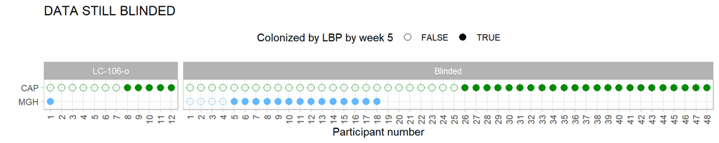

```r
col_by_week5 |>
  arrange(site, arm, LBP_colonization_by_week5) |>
  group_by(site, arm) |>
  mutate(participant_number = row_number() |> factor()) |>
  ungroup() |>
  ggplot(aes(x = participant_number, y = site |> fct_rev(), col = site, fill = site, shape = LBP_colonization_by_week5)) +
  geom_point(size = 3) +
  facet_grid(. ~ arm, scales = "free_x", space = "free_x") +
  guides(color = "none", fill = "none") +
  scale_shape_manual("Colonized by LBP by week 5", values = c(1, 16)) +
  scale_color_manual(values = get_site_colors()) +
  xlab("Participant number") + ylab("") +
  theme(
    legend.position = "top",
    axis.text.x = element_text(angle = 90, hjust = 1, vjust = 0.5)
  ) +
  ggtitle("DATA STILL BLINDED")
```

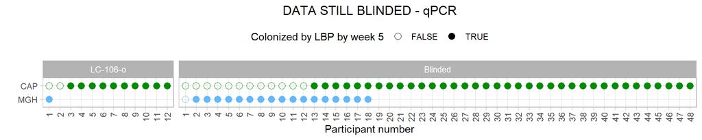

```r
col_by_week5_qPCR |>
  arrange(site, arm, LBP_colonization_by_week5) |>
  group_by(site, arm) |>
  mutate(participant_number = row_number() |> factor()) |>
  ungroup() |>
  ggplot(aes(x = participant_number, y = site |> fct_rev(), col = site, fill = site, shape = LBP_colonization_by_week5)) +
  geom_point(size = 3) +
  facet_grid(. ~ arm, scales = "free_x", space = "free_x") +
  guides(color = "none", fill = "none") +
  scale_shape_manual("Colonized by LBP by week 5", values = c(1, 16)) +
  scale_color_manual(values = get_site_colors()) +
  xlab("Participant number") + ylab("") +
  ggtitle("DATA STILL BLINDED - qPCR") +
  theme(
    legend.position = "top",
    axis.text.x = element_text(angle = 90, hjust = 1, vjust = 0.5),
    plot.title = element_text(hjust = 0.5)
  )
```

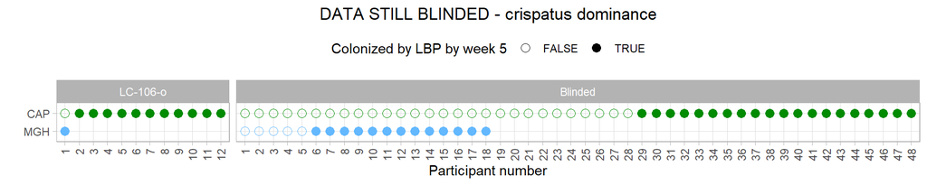

```r
crisp_dom_by_5week |>
  arrange(site, arm, crisp_dom_by_5week) |>
  group_by(site, arm) |>
  mutate(participant_number = row_number() |> factor()) |>
  ungroup() |>
  ggplot(aes(x = participant_number, y = site |> fct_rev(), col = site, fill = site, shape = crisp_dom_by_5week)) +
  geom_point(size = 3) +
  facet_grid(. ~ arm, scales = "free_x", space = "free_x") +
  guides(color = "none", fill = "none") +
  scale_shape_manual("Colonized by LBP by week 5", values = c(1, 16)) +
  scale_color_manual(values = get_site_colors()) +
  xlab("Participant number") + ylab("") +
  ggtitle("DATA STILL BLINDED - crispatus dominance") +
  theme(
    legend.position = "top",
    axis.text.x = element_text(angle = 90, hjust = 1, vjust = 0.5),
    plot.title = element_text(hjust = 0.5)
  )
```

```r
summary_table <-
  col_by_week5 |>
  group_by(site, arm) |>
  summarize(
    n = n(),
    n_success = sum(LBP_colonization_by_week5),
    .groups = "drop"
  ) |>
  mutate(
    p = n_success / n,
    CI = binom::binom.confint(n_success, n, method = "exact")
  )
```

```r
table_2 <-
  summary_table |>
  mutate(
    N_per_site_and_arm = str_c("N = ", n),
    LBP_strain_detected = str_c(n_success, " (", round(p * 100)," %)"),
    CI_text = str_c(round(CI$lower * 100), "% - ", round(CI$upper * 100), "%")
  ) |>
  dplyr::select(
    site, arm, N_per_site_and_arm, LBP_strain_detected, CI_text
  ) |>
  pivot_longer(-c(site, arm)) |>
  mutate(
    name =
      case_when(
        name == "N_per_site_and_arm" ~ "N participants",
        name == "LBP_strain_detected" ~ "n (%) participants\nwith LBP strain detected",
        name == "CI_text" ~ "95% CI"
      )
  ) |>
  pivot_wider(
    id_cols = c(site, name),
    names_from = arm,
    values_from = value, values_fill = ""
    )
```

```r
table_2 |>
  group_by(site) |>
  gt(caption = "DATA STILL BLINDED; Table 1: Colonization by week 5 by arm and site", row_group_as_column = TRUE) |>
  cols_width(
    "name" ~ px(200),
    everything() ~ px(120)
  ) |>
  cols_label(
    name = "",
    Blinded = "All blinded arms",
    # Pl = "Placebo",
    # `LC-106-7` = "LC-106<br>7 days",
    # `LC-106-3` = "LC-106<br>3 days",
    # `LC-106-o` = "LC-106<br>overlap",
    # `LC-115` = "LC-115<br>7 days",
    .fn = md
  )
```

DATA STILL BLINDED; Table 1: Colonization by week 5 by arm and site

|  |  | LC-106-o | All blinded arms |
| --- | --- | --- | --- |
| CAP | N participants | N = 12 | N = 48 |
|  | n (%) participants with LBP strain detected | 5 (42 %) | 23 (48 %) |
|  | 95% CI | 15% - 72% | 33% - 63% |
| MGH | N participants | N = 1 | N = 18 |
|  | n (%) participants with LBP strain detected | 1 (100 %) | 14 (78 %) |
|  | 95% CI | 3% - 100% | 52% - 94% |

#### Tests / models

```r
col_by_week5_agg <-
  col_by_week5 |>
  group_by(site, arm) |>
  summarise(success = LBP_colonization_by_week5 |> sum(), ntrials = n())

bfit <-
  brm(
    success | trials(ntrials) ~ arm + site + site:arm,
    data = col_by_week5_agg,
    family = binomial("logit")
    )
```

```r
summary(bfit)
plot(bfit, ask = FALSE)
bind_cols(col_by_week5_agg, predict(bfit))
# loo(bfit, moment_match = TRUE, reloo = TRUE)
# pp_check(bfit)
```

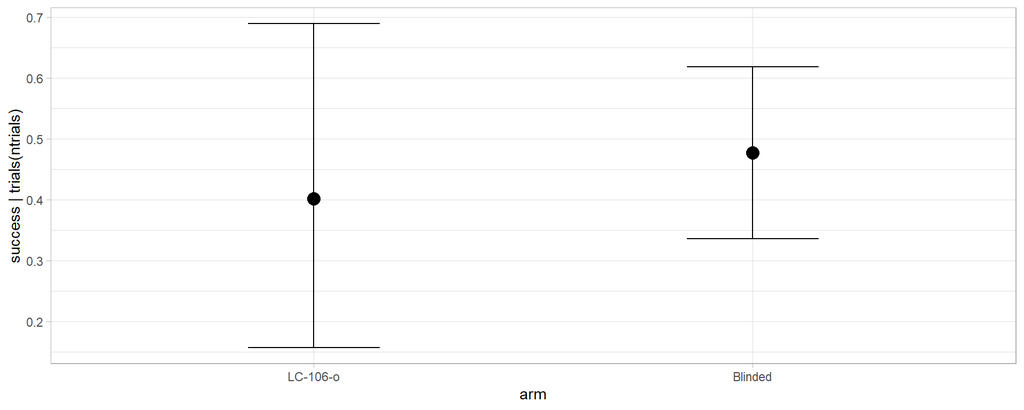

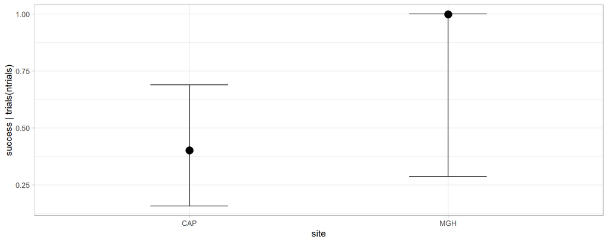

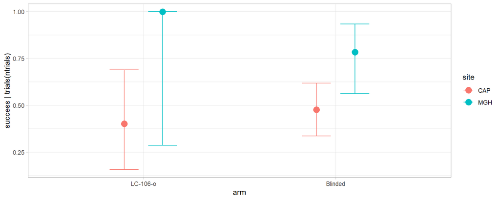

```r
plot_res <- plot(conditional_effects(bfit), ask = FALSE)
```

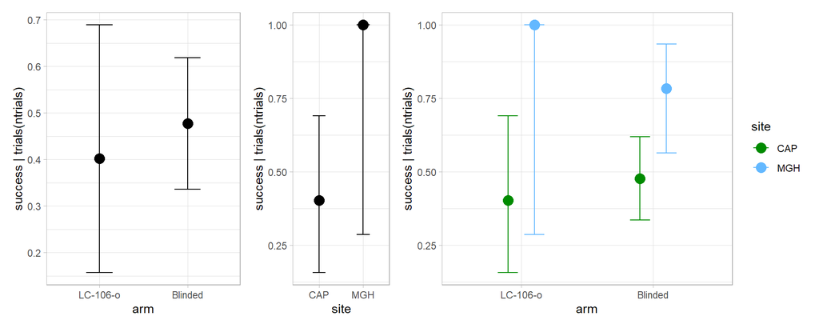

```r
plot_res <- lapply(plot_res, function(p) {
  p + scale_color_manual(values = get_site_colors())
})

Reduce(`+`, plot_res) +
  plot_layout(widths = c(2, 1, 3))
```

```r
model_results <- summary(bfit)$fixed
model_results <-
  model_results |>
  rownames_to_column("term") |>
  as_tibble() |>
  mutate(
    factor =
      case_when(
        str_detect(term, ":site") ~ "Arm x Site",
        str_detect(term, "^site") ~ "Site",
        str_detect(term, "^arm") ~ "Arm",
        TRUE ~ "Ref.",
      ),
    factor_level =
      term |>
      str_remove("arm") |> str_remove("site") |> str_replace(":"," x ") |>
      str_replace("6M", "6-") |> str_replace("CM", "C-")
  ) |>
  mutate(
    OR = ifelse(factor == "Ref.", NA, exp(Estimate)),
    lower_CI = ifelse(factor == "Ref.", NA, exp(`l-95% CI`)),
    upper_CI = ifelse(factor == "Ref.", NA, exp(`u-95% CI`))
  )
```

```r
model_results |>
  select(factor, factor_level, OR, lower_CI, upper_CI) |>
  gt() |>
  gt::fmt_number(
    decimals = 2, n_sigfig = 3
  )
```

| factor | factor_level | OR | lower_CI | upper_CI |
| --- | --- | --- | --- | --- |
| Ref. | Intercept | NA | NA | NA |
| Arm | Blinded | 1.38 | 0.375 | 5.26 |
| Site | MGH | 144,000 | 0.566 | 2,190,000,000,000,000,000 |
| Arm x Site | Blinded x MGH | 0.0000290 | 0.00000000000000000166 | 9.10 |

```r
model_results_arm <-
  model_results |>
  filter(factor == "Arm") |>
  mutate(
    OR = OR |> round(2) |> as.character(),
    CI = str_c(lower_CI |> round(2), " - ", upper_CI |> round(2))
    ) |>
  select(factor_level, OR, CI) |>
  pivot_longer(cols = -factor_level, names_to = "name", values_to = "value") |>
  pivot_wider(names_from = factor_level, values_from = value)
```

```r
table_2_with_model_results <-
  bind_rows(
    table_2,
    model_results_arm
  ) |>
  mutate(
    site = site |> str_replace_na(""),
    Pl =
      case_when(
        name == "OR" ~ "Ref.",
        name == "CI" ~ "",
        TRUE ~ Pl
      )
  )
```

```r
table_2_with_model_results |>
  group_by(site) |>
  gt(caption = "Table 2: Colonization by week 5 by arm and site", row_group_as_column = TRUE) |>
  cols_width(
    "name" ~ px(200),
    everything() ~ px(120)
  ) |>
  cols_label(
    name = "",
    Pl = "Placebo",
    `LC-106-7` = "LC-106<br>7 days",
    `LC-106-3` = "LC-106<br>3 days",
    `LC-106-o` = "LC-106<br>overlap",
    `LC-115` = "LC-115<br>7 days",
    .fn = md
  )
```

[output not shown]

### Colonization by week 5: RANDOM ARMS

```r
col_by_week5 <-
  mae[["col_LBP_mg"]] |> #primary_outcome
  as_tibble() |>
  dplyr::left_join(
    mae@colData |> as_tibble() |>
      select(uid, pid, visit_code, site, location, randomized, arm) |>
      mutate(.sample = uid),
    by = join_by(.sample)
  ) |>
  filter(randomized, visit_code == "1500", .feature == "colonized_LBP_by_mg") |>
  mutate(LBP_colonization_by_week5 = outcome) |>
  mutate(
    arm =
      case_when(
        (arm == "LC-106-o") ~ arm,
        (location == "US") ~ sample(c("Pl", "LC-106-7", "LC-115"), n(), replace = TRUE),
        (location == "SA") ~ sample(c("Pl", "LC-106-7", "LC-106-3", "LC-115"), n(), replace = TRUE),
        TRUE ~ "Blinded"
      ) |>
      factor(levels = c("Pl", "LC-106-7", "LC-106-3", "LC-106-o", "LC-115", "Blinded"))
  )
```

**Visualization of the primary outcome**

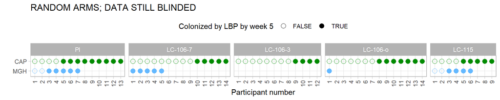

```r
col_by_week5 |>
  arrange(site, arm, LBP_colonization_by_week5) |>
  group_by(site, arm) |>
  mutate(participant_number = row_number() |> factor()) |>
  ungroup() |>
  ggplot(aes(x = participant_number, y = site |> fct_rev(), col = site, fill = site, shape = LBP_colonization_by_week5)) +
  geom_point(size = 3) +
  facet_grid(. ~ arm, scales = "free_x", space = "free_x") +
  guides(color = "none", fill = "none") +
  scale_shape_manual("Colonized by LBP by week 5", values = c(1, 16)) +
  scale_color_manual(values = get_site_colors()) +
  xlab("Participant number") + ylab("") +
  theme(
    legend.position = "top",
    axis.text.x = element_text(angle = 90, hjust = 1, vjust = 0.5)
  ) +
  ggtitle("RANDOM ARMS; DATA STILL BLINDED")
```

```r
summary_table <-
  col_by_week5 |>
  group_by(site, arm) |>
  summarize(
    n = n(),
    n_success = sum(LBP_colonization_by_week5),
    .groups = "drop"
  ) |>
  mutate(
    p = n_success / n,
    CI = binom::binom.confint(n_success, n, method = "exact")
  )
```

```r
table_2 <-
  summary_table |>
  mutate(
    N_per_site_and_arm = str_c("N = ", n),
    LBP_strain_detected = str_c(n_success, " (", round(p * 100)," %)"),
    CI_text = str_c(round(CI$lower * 100), "% - ", round(CI$upper * 100), "%")
  ) |>
  dplyr::select(
    site, arm, N_per_site_and_arm, LBP_strain_detected, CI_text
  ) |>
  pivot_longer(-c(site, arm)) |>
  mutate(
    name =
      case_when(
        name == "N_per_site_and_arm" ~ "N participants",
        name == "LBP_strain_detected" ~ "n (%) participants\nwith LBP strain detected",
        name == "CI_text" ~ "95% CI"
      )
  ) |>
  pivot_wider(
    id_cols = c(site, name),
    names_from = arm,
    values_from = value, values_fill = ""
    )
```

```r
table_2 |>
  group_by(site) |>
  gt(caption = "RANDOM ARMS, DATA STILL BLINDED; Table 1: Colonization by week 5 by arm and site", row_group_as_column = TRUE) |>
  cols_width(
    "name" ~ px(200),
    everything() ~ px(120)
  ) |>
  cols_label(
    name = "",
    Pl = "Placebo",
    `LC-106-7` = "LC-106<br>7 days",
    `LC-106-3` = "LC-106<br>3 days",
    `LC-106-o` = "LC-106<br>overlap",
    `LC-115` = "LC-115<br>7 days",
    .fn = md
  )
```

RANDOM ARMS, DATA STILL BLINDED; Table 1: Colonization by week 5 by arm and site

|  |  | Placebo | LC-106 7 days | LC-106 3 days | LC-106 overlap | LC-115 7 days |
| --- | --- | --- | --- | --- | --- | --- |
| CAP | N participants | N = 13 | N = 14 | N = 12 | N = 14 | N = 9 |
|  | n (%) participants with LBP strain detected | 9 (69 %) | 5 (36 %) | 4 (33 %) | 7 (50 %) | 5 (56 %) |
|  | 95% CI | 39% - 91% | 13% - 65% | 10% - 65% | 23% - 77% | 21% - 86% |
| MGH | N participants | N = 7 | N = 5 |  | N = 1 | N = 6 |
|  | n (%) participants with LBP strain detected | 5 (71 %) | 5 (100 %) |  | 1 (100 %) | 4 (67 %) |
|  | 95% CI | 29% - 96% | 48% - 100% |  | 3% - 100% | 22% - 96% |

#### Tests / models

```r
col_by_week5_agg <-
  col_by_week5 |>
  group_by(site, arm) |>
  summarise(success = LBP_colonization_by_week5 |> sum(), ntrials = n())

bfit <-
  brm(
    success | trials(ntrials) ~ arm + site + site:arm,
    data = col_by_week5_agg,
    family = binomial("logit")
    )
```

```r
summary(bfit)
plot(bfit, ask = FALSE)
bind_cols(col_by_week5_agg, predict(bfit))
# loo(bfit, moment_match = TRUE, reloo = TRUE)
# pp_check(bfit)
```

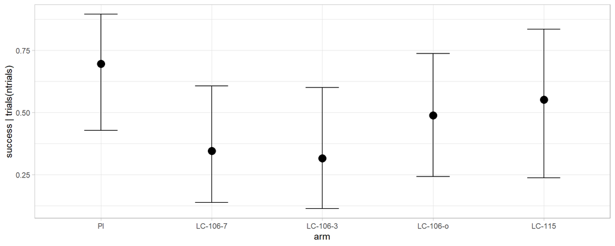

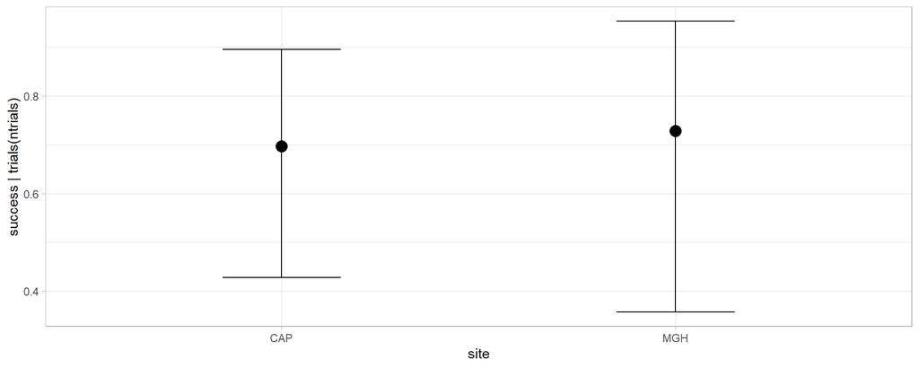

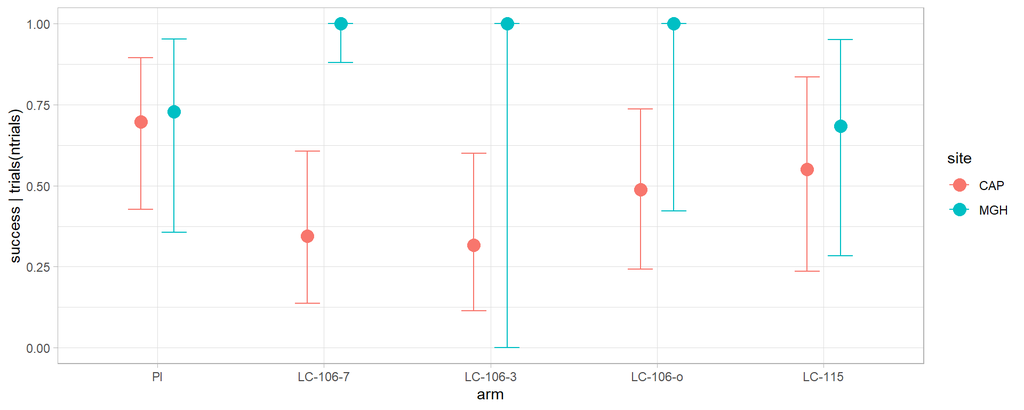

```r
plot_res <- plot(conditional_effects(bfit), ask = FALSE)
```

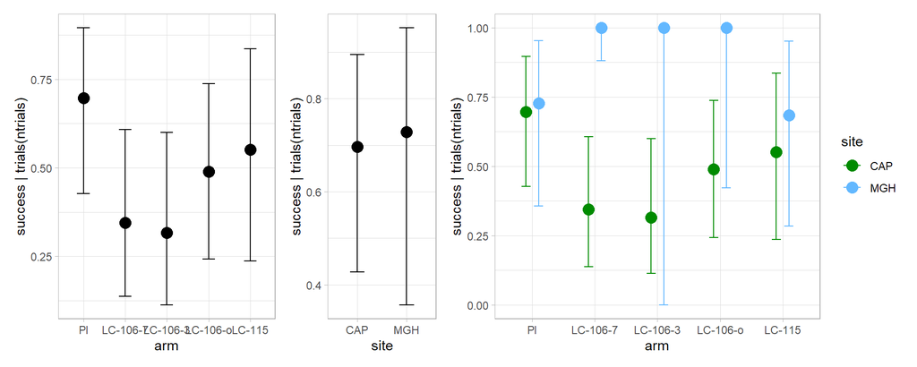

```r
plot_res <- lapply(plot_res, function(p) {
  p + scale_color_manual(values = get_site_colors())
})

Reduce(`+`, plot_res) +
  plot_layout(widths = c(2, 1, 3))
```

```r
model_results <- summary(bfit)$fixed
model_results <-
  model_results |>
  rownames_to_column("term") |>
  as_tibble() |>
  mutate(
    factor =
      case_when(
        str_detect(term, ":site") ~ "Arm x Site",
        str_detect(term, "^site") ~ "Site",
        str_detect(term, "^arm") ~ "Arm",
        TRUE ~ "Ref.",
      ),
    factor_level =
      term |>
      str_remove("arm") |> str_remove("site") |> str_replace(":"," x ") |>
      str_replace("6M", "6-") |> str_replace("CM", "C-")
  ) |>
  mutate(
    OR = ifelse(factor == "Ref.", NA, exp(Estimate)),
    lower_CI = ifelse(factor == "Ref.", NA, exp(`l-95% CI`)),
    upper_CI = ifelse(factor == "Ref.", NA, exp(`u-95% CI`))
  )
```

```r
model_results |>
  select(factor, factor_level, OR, lower_CI, upper_CI) |>
  gt() |>
  gt::fmt_number(
    decimals = 2, n_sigfig = 3
  )
```

| factor | factor_level | OR | lower_CI | upper_CI |
| --- | --- | --- | --- | --- |
| Ref. | Intercept | NA | NA | NA |
| Arm | LC-106-7 | 0.219 | 0.0378 | 1.06 |
| Arm | LC-106-3 | 0.193 | 0.0337 | 1.00 |
| Arm | LC-106-o | 0.408 | 0.0766 | 1.98 |
| Arm | LC-115 | 0.522 | 0.0788 | 3.14 |
| Site | MGH | 1.20 | 0.146 | 11.5 |
| Arm x Site | LC-106-7 x MGH | 1,730,000,000,000 | 8.11 | 86,900,000,000,000,002,600,464,260,628,840,000,662,882,606,668,644,424 |
| Arm x Site | LC-106-3 x MGH | 0 | 0 | Inf |
| Arm x Site | LC-106-o x MGH | 95,500,000,000 | 0.506 | 867,000,000,000,000,137,842,248,448,642,604,404,264,820,626,064 |
| Arm x Site | LC-115 x MGH | 1.54 | 0.0576 | 44.0 |

```r
model_results_arm <-
  model_results |>
  filter(factor == "Arm") |>
  mutate(
    OR = OR |> round(2) |> as.character(),
    CI = str_c(lower_CI |> round(2), " - ", upper_CI |> round(2))
    ) |>
  select(factor_level, OR, CI) |>
  pivot_longer(cols = -factor_level, names_to = "name", values_to = "value") |>
  pivot_wider(names_from = factor_level, values_from = value) |>
  mutate(
    name =
      case_when(
        name == "OR" ~ "OR",
        name == "CI" ~ "95% CI",
        TRUE ~ name
      )
  )
```

```r
table_2_with_model_results <-
  bind_rows(
    table_2,
    model_results_arm
  ) |>
  mutate(
    site = site |> str_replace_na(""),
    Pl =
      case_when(
        name == "OR" ~ "Ref.",
        str_detect(name, "CI") ~ "",
        TRUE ~ Pl
      )
  )
```

```r
table_2_with_model_results |>
  group_by(site) |>
  gt(caption = "Table 2: Colonization by week 5 by arm and site", row_group_as_column = TRUE) |>
  cols_width(
    "name" ~ px(150),
    everything() ~ px(120)
  ) |>
  cols_label(
    name = "",
    Pl = "Placebo",
    `LC-106-7` = "LC-106<br>7 days",
    `LC-106-3` = "LC-106<br>3 days",
    `LC-106-o` = "LC-106<br>overlap",
    `LC-115` = "LC-115<br>7 days",
    .fn = md
  )
```

Table 2: Colonization by week 5 by arm and site

|  |  | Placebo | LC-106 7 days | LC-106 3 days | LC-106 overlap | LC-115 7 days |
| --- | --- | --- | --- | --- | --- | --- |
| CAP | N participants | N = 13 | N = 14 | N = 12 | N = 14 | N = 9 |
|  | n (%) participants with LBP strain detected | 9 (69 %) | 5 (36 %) | 4 (33 %) | 7 (50 %) | 5 (56 %) |
|  | 95% CI |  | 13% - 65% | 10% - 65% | 23% - 77% | 21% - 86% |
| MGH | N participants | N = 7 | N = 5 |  | N = 1 | N = 6 |
|  | n (%) participants with LBP strain detected | 5 (71 %) | 5 (100 %) |  | 1 (100 %) | 4 (67 %) |
|  | 95% CI |  | 48% - 100% |  | 3% - 100% | 22% - 96% |
|  | OR | Ref. | 0.22 | 0.19 | 0.41 | 0.52 |
|  | 95% CI |  | 0.04 - 1.06 | 0.03 - 1 | 0.08 - 1.98 | 0.08 - 3.14 |

### Kinetics of colonization

#### Total proportions of LBP isolates

```r
total_rel_ab_of_LBP <-
  mae[["mg"]] |>
  as_tibble() |>
  filter(!is.na(LBP)) |>
  group_by(.sample, uid) |>
  summarize(
    total_LBP_rel_ab = sum(rel_abs_bact, na.rm = TRUE),
    .groups = "drop"
  )

total_rel_ab_of_LBP <-
  total_rel_ab_of_LBP |>
  dplyr::left_join(mae |> colData() |> as_tibble(), by = join_by(uid))
```

```r
g_tot_prop_LBP_strains <-
  total_rel_ab_of_LBP |>
  filter(visit_type == "Clinic", !is.na(arm)) |>
  ggplot(aes(x = study_week, y = total_LBP_rel_ab, col = arm)) +
  geom_line(aes(group = pid), alpha = 0.5) +
  geom_point(size = 0.5, alpha = 0.5) +
  facet_grid(site ~ arm) +
  scale_x_continuous("Study weeks", breaks = c(0:5,7,9,12), minor_breaks = 0:12) +
  scale_y_continuous(
    "Total proportion of LBP strains", labels = scales::percent,
    breaks = seq(0, 1, by = 0.2)
  ) +
  expand_limits(y = 0) +
  scale_color_manual(values = get_arm_colors()) +
  guides(col = "none") +
  ggtitle(make_title(mae))
```

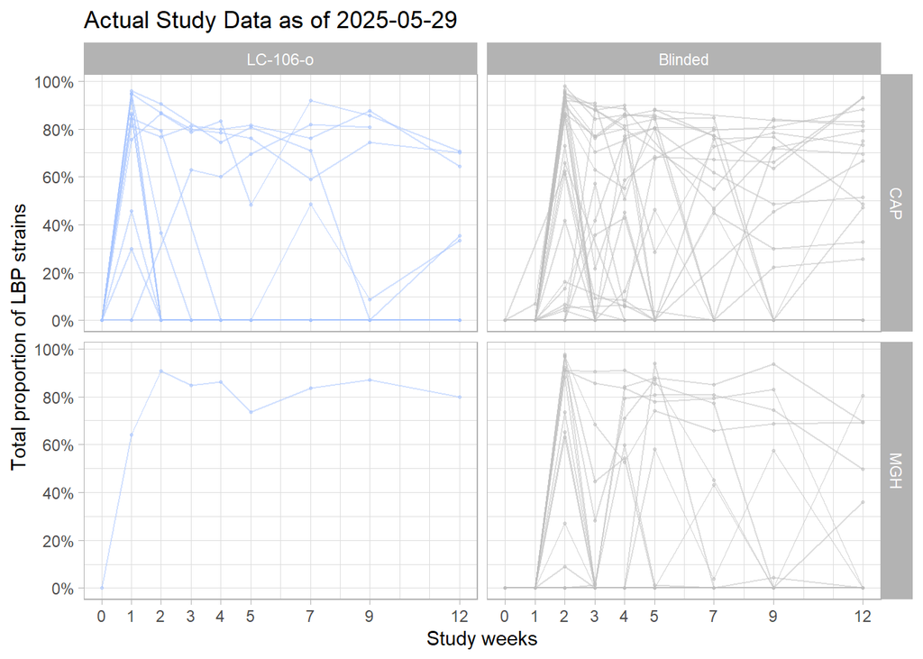

```r
g_tot_prop_LBP_strains
```

#### Proportions of participants who colonized

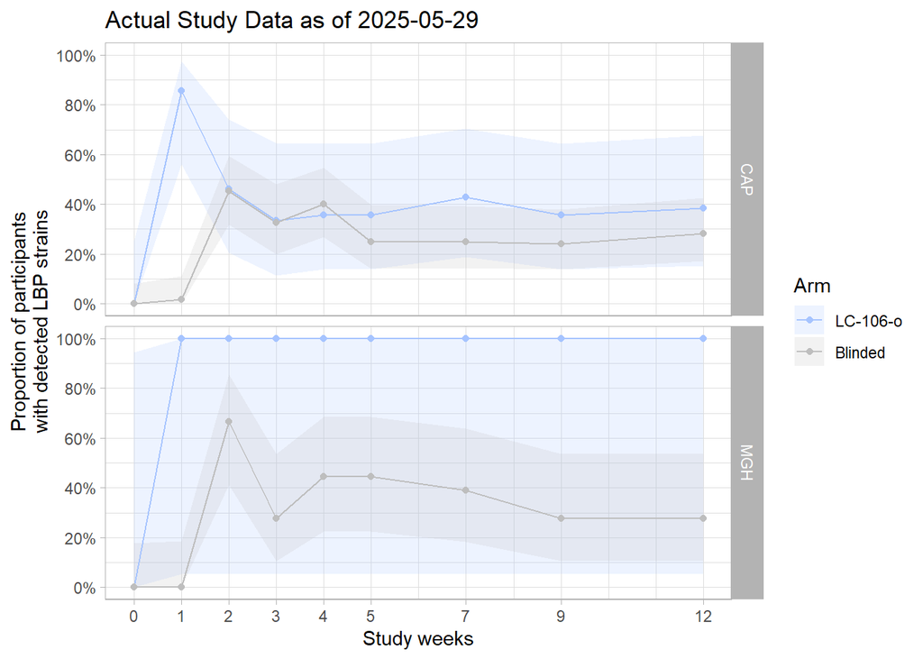

```r
g_prop_colonized_by <-
  total_rel_ab_of_LBP |>
  filter(!is.na(arm)) |>
  group_by(site, arm, study_week) |>
  summarize(
    prop_who_colonized_at = mean(total_LBP_rel_ab > 0.05),
    CI_low =
      prop.test(
        x = sum(total_LBP_rel_ab > 0.05), n = n(),
        conf.level = 0.95)$conf.int[1],
    CI_high =
      prop.test(
        x = sum(total_LBP_rel_ab > 0.05), n = n(),
        conf.level = 0.95)$conf.int[2],
    .groups = "drop"
  ) |>
  ggplot(aes(x = study_week, y = prop_who_colonized_at, col = arm)) +
  geom_ribbon(
    aes(ymin = CI_low, ymax = CI_high, fill = arm),
    alpha = 0.2, color = NA
  ) +
  geom_line() +
  geom_point() +
  facet_grid(site ~ .) +
  scale_x_continuous("Study weeks", breaks = c(0:5,7,9,12), minor_breaks = 0:12) +
  scale_y_continuous(
    "Proportion of participants\nwith detected LBP strains", labels = scales::percent,
    breaks = seq(0, 1, by = 0.2)
  ) +
  expand_limits(y = 0) +
  scale_color_manual("Arm", values = get_arm_colors()) +
  scale_fill_manual("Arm", values = get_arm_colors()) +
  ggtitle(make_title(mae))

g_prop_colonized_by
```

#### Figure 2

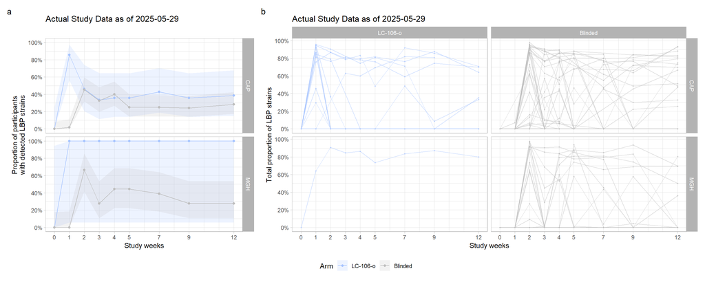

```r
 g_prop_colonized_by +
  g_tot_prop_LBP_strains +
  plot_layout(guides = "collect", widths = c(1, 2)) +
  plot_annotation(tag_level = "a") &
  theme(legend.position = "bottom")
```

### Microbiota trajectories

```r
rel_abs <-
  mae[["mg"]] |>
  as_tibble() |>
  select(
    .feature, .sample, uid, rel_abs_bact,
    taxon_label, genus, LBP, strain_origin
    )
```

```r
rel_abs <-
  rel_abs |>
  group_by(.feature) |>
  mutate(max_rel_ab = max(rel_abs_bact, na.rm = TRUE)) |>
  ungroup() |>
  arrange(is.na(LBP), -max_rel_ab) |>
  mutate(.feature = .feature |> fct_inorder()) |>
  mutate(
    taxon =
      case_when(
        as.numeric(.feature) <= 29 ~ taxon_label,
        TRUE ~ "Other"
      )
  ) |>
  arrange(is.na(LBP), LBP, genus != "Lactobacillus", -max_rel_ab) |>
  mutate(taxon = taxon |> fct_inorder() |> fct_relevel("Other", after = Inf))
```

```r
rel_abs_agg <-
  rel_abs |>
  group_by(uid, taxon, LBP, strain_origin) |>
  summarize(rel_ab = sum(rel_abs_bact), .groups = "drop") |>
  dplyr::left_join(mae |> colData() |> as_tibble(), by = join_by(uid))
```

```r
g_trajectories <-
  rel_abs_agg |>
  mutate(study_week = case_when(visit_code == "0000" ~ -1, TRUE ~ study_week)) |>
  filter(randomized != 0, visit_type == "Clinic", !is.na(study_week)) |>
  group_by(pid) |>
  mutate(
    tot_LC115 = sum(rel_ab[LBP == "LC-115"]),
    tot_LBP = sum(rel_ab[!is.na(LBP)])
    ) |>
  ungroup() |>
  arrange(-tot_LC115, -tot_LBP) |>
  mutate(pid = pid |> fct_inorder()) |>
  ggplot(aes(y = rel_ab, x = pid, fill = taxon)) +
  geom_col() +
  facet_grid(study_week ~ arm + site, scales = "free", space = "free") +
  # theme(panel.spacing.x = unit(0, "points")) +
  scale_fill_manual(
    values = get_taxa_colors(rel_abs_agg$taxon |> levels()),
    guide = guide_legend(ncol = 1)
    ) +
  scale_y_continuous(
    "relative abundance", labels = scales::percent,
    breaks = seq(0, 0.5, by = 0.5), minor_breaks = seq(0, 1, by = 0.25)
  ) +
  scale_x_discrete("Participants") +
  theme(
    strip.text.y = element_text(angle = 0, hjust = 0),
    axis.text.x = element_text(angle = 90, hjust = 1, vjust = 0.5)
  )
```

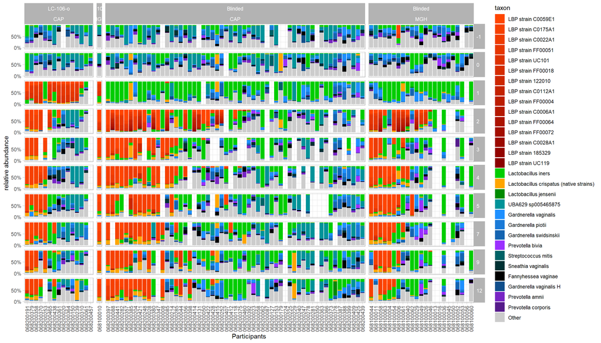

```r
g_trajectories
```

### Individual LBP strains by sites

```r
LBP_strains <-
  mae[["mg"]] |>
  as_tibble() |>
  filter(!is.na(LBP)) |>
  select(.feature, .sample, uid, rel_abs_bact, LBP, strain_origin) |>
  left_join(mae |> colData() |> as_tibble())
```

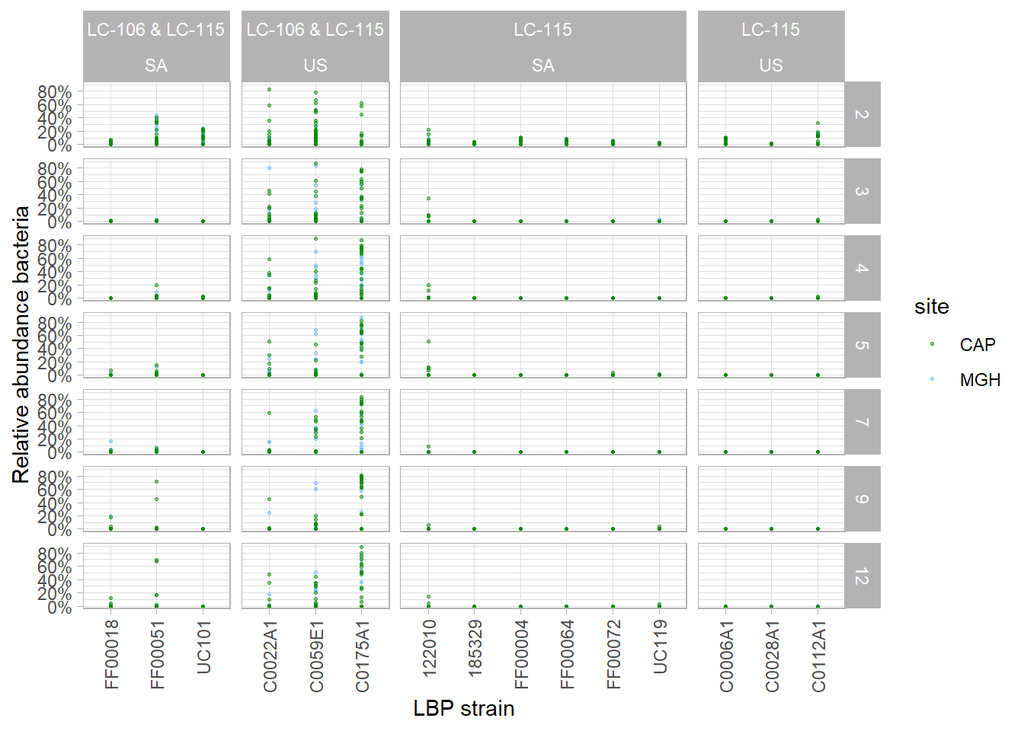

```r
LBP_strains |>
  filter(!is.na(arm), !is.na(study_week), study_week >= 2) |>
  ggplot() +
  aes(x = .feature, y = rel_abs_bact, col = site) +
  geom_point(alpha = 0.5, size = 0.5) +
  # geom_boxplot(outlier.size = 0.5) +
  facet_grid(study_week ~ LBP + strain_origin , scales = "free_x", space = "free_x") +
  xlab("LBP strain") +
  scale_y_continuous(
    "Relative abundance bacteria", labels = scales::percent,
    breaks = seq(0, 1, by = 0.2)
  ) +
  scale_color_manual(values = get_site_colors()) +
  theme(
    axis.text.x = element_text(angle = 90, hjust = 1, vjust = 0.5)
  )
```

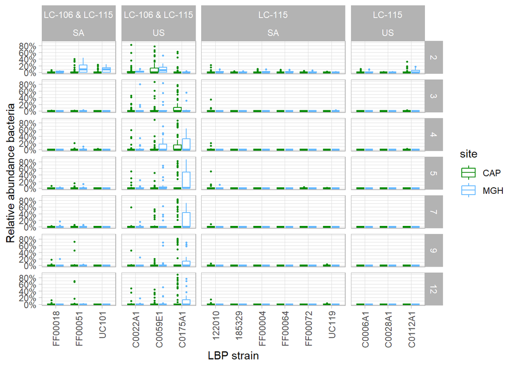

```r
LBP_strains |>
  filter(!is.na(arm), !is.na(study_week), study_week >= 2) |>
  ggplot() +
  aes(x = .feature, y = rel_abs_bact, col = site) +
  # geom_point(alpha = 0.5, size = 0.5) +
  geom_boxplot(outlier.size = 0.5) +
  facet_grid(study_week ~ LBP + strain_origin , scales = "free_x", space = "free_x") +
  xlab("LBP strain") +
  scale_y_continuous(
    "Relative abundance bacteria", labels = scales::percent,
    breaks = seq(0, 1, by = 0.2)
  ) +
  scale_color_manual(values = get_site_colors()) +
  theme(
    axis.text.x = element_text(angle = 90, hjust = 1, vjust = 0.5)
  )
```

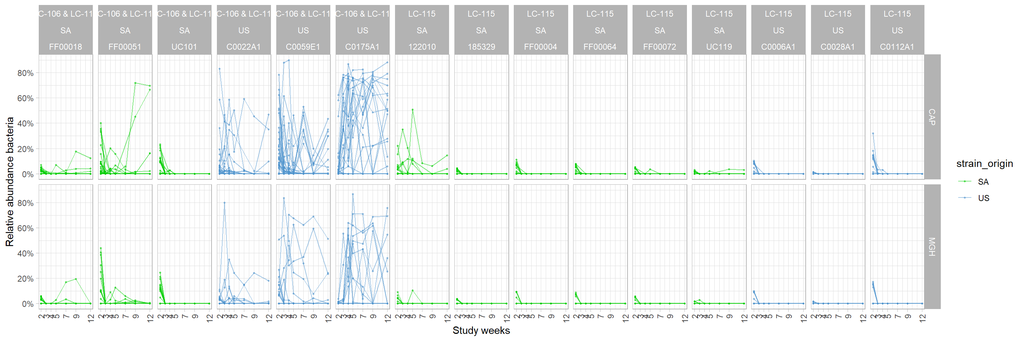

```r
LBP_strains |>
  filter(!is.na(arm), !is.na(study_week), study_week >= 2) |>
  ggplot() +
  aes(x = study_week, y = rel_abs_bact, col = strain_origin) +
  geom_point(alpha = 0.5, size = 0.5) +
  geom_line(aes(group = pid), alpha = 0.5) +
  facet_grid(site ~ LBP + strain_origin + .feature , scales = "free_x", space = "free_x") +
  xlab("Study week") +
  scale_y_continuous(
    "Relative abundance bacteria", labels = scales::percent,
    breaks = seq(0, 1, by = 0.2)
  ) +
  #scale_color_manual(values = colorspace::darken(scale_colour_hue()$palette(2), amount = 0.4)) +
  scale_color_manual(values = get_origin_colors()) +
  scale_x_continuous("Study weeks", breaks = c(0:5,7,9,12), minor_breaks = 0:12) +
  theme(
    axis.text.x = element_text(angle = 90, hjust = 1, vjust = 0.5)
  )
```